# Data

## Underlying Data

Data used for this project was obtained from the Kaggle website. One of Kaggles main features is it’s competition platform.[^1] Kaggle allows users to organise and host competitions. Access to the data required registering with Kaggle and joining the American Express - Default Prediction competition.[^2] American Express is the largest payment card issuer in the world.[^3] This competition provides an industrial scale data set to build a machine learning model to predict credit card default using time-series behavioural data and anonymised customer profile information over the period of March 2017 to March 2018. The target binary variable i.e. default is calculated by observing 18 months performance window after the latest credit card statement, and if the customer does not pay due amount in 120 days after their latest statement date it is considered a default event.

## Data Structure

**train_labels.csv**  
A list of unique customer identifiers `customer_ID` with the target label `target` indicating a default event with `target = 1` indicating a default, `target = 0` indicating no default. There are 458913 observations in this data meaning 458913 unique AMEX customers. 74.1% of customers in the data did not default on payment while 25.9% defaulted.

**train_data.csv**  
This is a tabular data set corresponding to the training data, consisting of 190 features and over 5.5 million observations. It contains multiple statement dates per customer_ID, each observation corresponds to a monthly statement for a customer. The data is ordered firstly by `customer_ID`, corresponding with the train_labels.csv file and secondly ordered chronologically by statement date. The dataset contains aggregated profile features for each customer at each statement date. There are 177 numeric features which are anonymised and normalized, and fall into the following general categories:

Variable Categories

| Variable Name | Category |
| --- | --- |
| D_* | Delinquency variables |
| S_* | Spend variables |
| P_* | Payment variables |
| B_* | Balance variables |
| R_* | Risk variables |

There are 11 categorical variables - B_30, B_38, D_114, D_116, D_117, D_120, D_126, D_63, D_64, D_66 and D_68.

The remaining two unaccounted for features are the variable S_2 which contains the date of the statement and `customer_ID` which can used to match to the target label.

## Feature Engineering

**Dimension Reduction**  
A number of feature engineering steps were performed independently on the predictor variables. This was done in order to create a more manageable sized data set with uninformative features removed. Most ML algorithms do not allow missing or NA values as part of the inputs. Features dominated by a single value or small range of values do not hold much information and would not contribute to an effective classification model. Highly intercorrelated features particularly affect the interpretation of a regression model as then the regression coefficients are not unique and have influences from other features. More broadly, multi-collinear features increase dimensionality which increases the computational intensity of ML algorithms without adding extra information which could be used to predict the target.  
Columns with a proportion of NA values higher than 10% or variance lower than 0.001 were identified. A list of these columns were added to a list of single columns from any pair with pairwise correlation greater than a high correlation threshold of 0.9. This process reduced the number of features from 189 to 129.

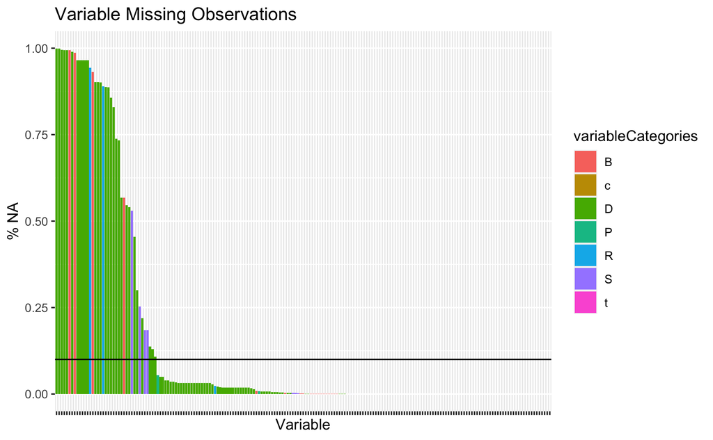

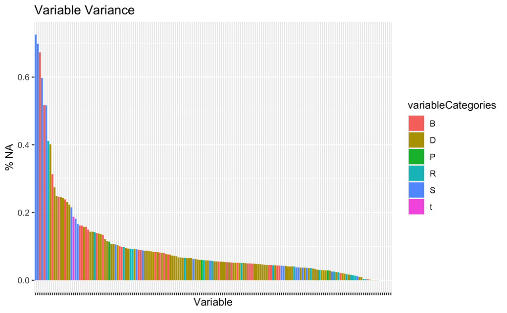

Proportion Missing, and Variance of Feature Columns

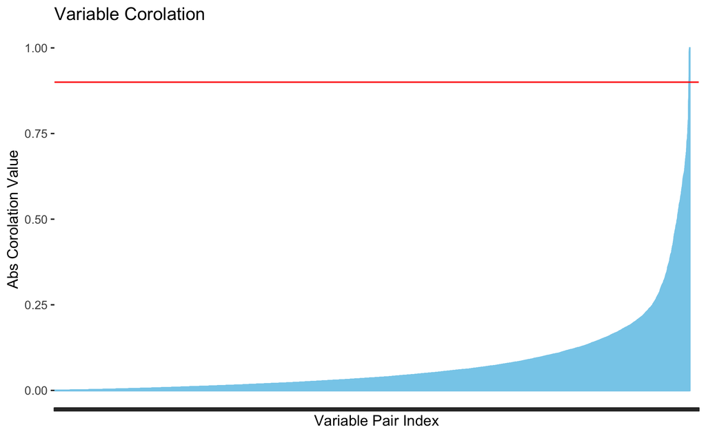

Pairwise Correlation of Feature Variable

**Noise Removal**  
As part of anonymising the data, noise was injected into a number of rational variables. This can be observed by plotting the histogram of variables. Viewing the variables S6, D111 and B16 we can see that there are pillars of high frequencies with no observations between them. Each variable has a different interval for which values are seen, but the commonality is the width of each pillar is 0.01. This can be easily rationalized trying to anonymising the standard interval for US currency ($\$ 0.01$), but has been applied across a number of discrete variables to make them continuous.

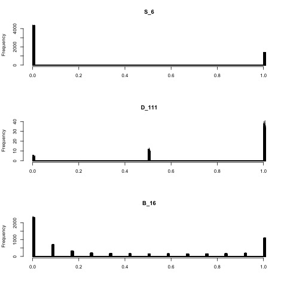

Sample of features with noise added

To identify these intervals where noise occurs a one sided Kolmogorov-Smirnov goodness of fit test is implemented. The Kolmogorov-Smirnov test is a nonparametric test which measures agreement between the cumulative distribution function of observed data to a specified distribution . In this case, we are comparing to a uniform $U(0,0.01)$ distribution for each test.

The hypothesis being tested is:  
$H_0 :$ The sample comes from the specified theoretical distribution  
$H_A :$ The sample does not comes from the specified theoretical distribution

The test statistic is the absolute value of the largest distance between the two distributions functions.
$$D
= sup_x |F_n(X) - F(X)|$$

where $n$ is the sample size, $F_n(X)$ is the observed cumulative frequency distribution of a random sample of n observations and $F(X)$ is the theoretical cumulative distribution function

This test statistic is evaluated against the K-S tables to give a p-value. For evaluating if noise $[0,0.01]$ had been added the data, the bounds for each noise pillar are found iteratively by taking the smallest value in the dataset and adding $0.01$ to it to create and upper bound. All values that lie within this pillar are first scaled to the interval $[0,0.01]$ by taking the remainder modulo $0.01$. The scaled values are sampled using the Kolmogorov-Smirnov test against the $U(0,0.01)$ distribution. These values are then omitted and the next minimum data point is selected.

There are two values of interest:  
**1)** The interval between observed values with noise removed  
Each minimum value recorded is rounded to the nearest rational number, with the smallest accepted value being 0.01. Limiting the lower bound of acceptable rational numbers removes the possibility of overlap between pillars. We accept the interval as the most observed interval across all pillars, as values are assumed uniformly discrete.

**2)** The acceptances criteria for if noise has been added to the data  
The acceptance criteria is the percentage of total pillars that do not reject the null hypothesis. As we are observing the null hypothesis, on each test with $p > 0.05$ we can only not reject that the observed values come from a uniform distribution. As such a high threshold of 0.95 for the acceptance criteria is chosen to ensure variables selected are highly likely to have had noise added.

Variables that were identified as having noise added are scaled by the gap between observed values and converted to integers.

**Final Data**  
This cleansed data was merged with the default labels data. Due to computational limitations, the full data set could not reasonably be used in any full capacity to train computationally intensive ML algorithms. To reduce the length of the data, the most recent statement data per customer_id was retained and all preceding months data was dropped. This reduced the data to its final form of 458’913 individual customer observations and 129 features which was used for further analysis.

[^1]: https://www.kaggle.com/docs/competitions
[^2]: https://www.kaggle.com/competitions/amex-default-prediction/data
[^3]: https://about.americanexpress.com/our-company/our-business/our-business/default.aspx